# Prosper Loan Data Visualization

## Preliminary Wrangling

> This data set contains 113,937 loans with 81 variables on each loan, including loan amount, borrower rate (or interest rate), current loan status, borrower income, and many others. I will narrow my analysis on 18 variables.

```python
# import all packages and set plots to be embedded inline
import numpy as np
import pandas as pd
import matplotlib.pyplot as plt
import seaborn as sb

%matplotlib inline
```

```python
# Load dataset and look at the top 5 rows
df = pd.read_csv('prosperLoanData.csv')
df.head(5)
```

|  | ListingKey | ListingNumber | ListingCreationDate | CreditGrade | Term | LoanStatus | ClosedDate | BorrowerAPR | BorrowerRate | LenderYield | EstimatedEffectiveYield | EstimatedLoss | EstimatedReturn | ProsperRating (numeric) | ProsperRating (Alpha) | ProsperScore | ListingCategory (numeric) | BorrowerState | Occupation | EmploymentStatus | EmploymentStatusDuration | IsBorrowerHomeowner | CurrentlyInGroup | GroupKey | DateCreditPulled | CreditScoreRangeLower | CreditScoreRangeUpper | FirstRecordedCreditLine | CurrentCreditLines | … |
| --- | --- | --- | --- | --- | --- | --- | --- | --- | --- | --- | --- | --- | --- | --- | --- | --- | --- | --- | --- | --- | --- | --- | --- | --- | --- | --- | --- | --- | --- | --- |
| 0 | 1021339766868145413AB3B | 193129 | 09:29.3 | C | 36 | Completed | 2009-08-14 0:00 | 0.16516 | 0.1580 | 0.1380 | NaN | NaN | NaN | NaN | NaN | NaN | 0 | CO | Other | Self-employed | 2.0 | True | True | NaN | 41:46.8 | 640.0 | 659.0 | 2001-10-11 0:00 | 5.0 | … |
| 1 | 10273602499503308B223C1 | 1209647 | 28:07.9 | NaN | 36 | Current | NaN | 0.12016 | 0.0920 | 0.0820 | 0.07960 | 0.0249 | 0.05470 | 6.0 | A | 7.0 | 2 | CO | Professional | Employed | 44.0 | False | False | NaN | 2014-02-27 8:28 | 680.0 | 699.0 | 1996-03-18 0:00 | 14.0 | … |
| 2 | 0EE9337825851032864889A | 81716 | 00:47.1 | HR | 36 | Completed | 2009-12-17 0:00 | 0.28269 | 0.2750 | 0.2400 | NaN | NaN | NaN | NaN | NaN | NaN | 0 | GA | Other | Not available | NaN | False | True | 783C3371218786870A73D20 | 09:10.1 | 480.0 | 499.0 | 2002-07-27 0:00 | NaN | … |
| 3 | 0EF5356002482715299901A | 658116 | 02:35.0 | NaN | 36 | Current | NaN | 0.12528 | 0.0974 | 0.0874 | 0.08490 | 0.0249 | 0.06000 | 6.0 | A | 9.0 | 16 | GA | Skilled Labor | Employed | 113.0 | True | False | NaN | 2012-10-22 11:02 | 800.0 | 819.0 | 1983-02-28 0:00 | 5.0 | … |
| 4 | 0F023589499656230C5E3E2 | 909464 | 38:39.1 | NaN | 36 | Current | NaN | 0.24614 | 0.2085 | 0.1985 | 0.18316 | 0.0925 | 0.09066 | 3.0 | D | 4.0 | 2 | MN | Executive | Employed | 44.0 | True | False | NaN | 2013-09-14 18:38 | 680.0 | 699.0 | 2004-02-20 0:00 | 19.0 | … |

```python
# Check the dataset for data types, null values, number of rows, number of columns, duplicated values, and basic statistics for
# each variable including mean, min, and max
print(df.shape)
print(df.info())
```

```
(113937, 81)
<class 'pandas.core.frame.DataFrame'>
RangeIndex: 113937 entries, 0 to 113936
Data columns (total 81 columns):
ListingKey                             113937 non-null object
ListingNumber                          113937 non-null int64
ListingCreationDate                    113937 non-null object
CreditGrade                            28953 non-null object
Term                                   113937 non-null int64
LoanStatus                             113937 non-null object
ClosedDate                             55089 non-null object
BorrowerAPR                            113912 non-null float64
BorrowerRate                           113937 non-null float64
LenderYield                            113937 non-null float64
EstimatedEffectiveYield                84853 non-null float64
EstimatedLoss                          84853 non-null float64
EstimatedReturn                        84853 non-null float64
ProsperRating (numeric)                84853 non-null float64
ProsperRating (Alpha)                  84853 non-null object
ProsperScore                           84853 non-null float64
ListingCategory (numeric)              113937 non-null int64
BorrowerState                          108422 non-null object
Occupation                             110349 non-null object
EmploymentStatus                       111682 non-null object
EmploymentStatusDuration               106312 non-null float64
IsBorrowerHomeowner                    113937 non-null bool
CurrentlyInGroup                       113937 non-null bool
GroupKey                               13341 non-null object
DateCreditPulled                       113937 non-null object
CreditScoreRangeLower                  113346 non-null float64
CreditScoreRangeUpper                  113346 non-null float64
FirstRecordedCreditLine                113240 non-null object
CurrentCreditLines                     106333 non-null float64
OpenCreditLines                        106333 non-null float64
TotalCreditLinespast7years             113240 non-null float64
OpenRevolvingAccounts                  113937 non-null int64
OpenRevolvingMonthlyPayment            113937 non-null int64
InquiriesLast6Months                   113240 non-null float64
TotalInquiries                         112778 non-null float64
CurrentDelinquencies                   113240 non-null float64
```

[output cut: 33 more lines]

```
LP_CustomerPrincipalPayments           113937 non-null float64
LP_InterestandFees                     113937 non-null float64
LP_ServiceFees                         113937 non-null float64
LP_CollectionFees                      113937 non-null float64
LP_GrossPrincipalLoss                  113937 non-null float64
LP_NetPrincipalLoss                    113937 non-null float64
LP_NonPrincipalRecoverypayments        113937 non-null float64
PercentFunded                          113937 non-null float64
Recommendations                        113937 non-null int64
InvestmentFromFriendsCount             113937 non-null int64
InvestmentFromFriendsAmount            113937 non-null float64
Investors                              113937 non-null int64
dtypes: bool(3), float64(49), int64(12), object(17)
memory usage: 68.1+ MB
None
```

```python
df.describe()
```

|  | ListingNumber | Term | BorrowerAPR | BorrowerRate | LenderYield | EstimatedEffectiveYield | EstimatedLoss | EstimatedReturn | ProsperRating (numeric) | ProsperScore | ListingCategory (numeric) | EmploymentStatusDuration | CreditScoreRangeLower | CreditScoreRangeUpper | CurrentCreditLines | OpenCreditLines | TotalCreditLinespast7years | OpenRevolvingAccounts | OpenRevolvingMonthlyPayment | InquiriesLast6Months | TotalInquiries | CurrentDelinquencies | AmountDelinquent | DelinquenciesLast7Years | PublicRecordsLast10Years | PublicRecordsLast12Months | RevolvingCreditBalance | BankcardUtilization | AvailableBankcardCredit | … |
| --- | --- | --- | --- | --- | --- | --- | --- | --- | --- | --- | --- | --- | --- | --- | --- | --- | --- | --- | --- | --- | --- | --- | --- | --- | --- | --- | --- | --- | --- | --- |
| count | 1.139370e+05 | 113937.000000 | 113912.000000 | 113937.000000 | 113937.000000 | 84853.000000 | 84853.000000 | 84853.000000 | 84853.000000 | 84853.000000 | 113937.000000 | 106312.000000 | 113346.000000 | 113346.000000 | 106333.000000 | 106333.000000 | 113240.000000 | 113937.00000 | 113937.000000 | 113240.000000 | 112778.000000 | 113240.000000 | 106315.000000 | 112947.000000 | 113240.000000 | 106333.000000 | 1.063330e+05 | 106333.000000 | 106393.000000 | … |
| mean | 6.278857e+05 | 40.830248 | 0.218828 | 0.192764 | 0.182701 | 0.168661 | 0.080306 | 0.096068 | 4.072243 | 5.950067 | 2.774209 | 96.071582 | 685.567731 | 704.567731 | 10.317192 | 9.260164 | 26.754539 | 6.96979 | 398.292161 | 1.435085 | 5.584405 | 0.592052 | 984.507059 | 4.154984 | 0.312646 | 0.015094 | 1.759871e+04 | 0.561309 | 11210.225447 | … |
| std | 3.280762e+05 | 10.436212 | 0.080364 | 0.074818 | 0.074516 | 0.068467 | 0.046764 | 0.030403 | 1.673227 | 2.376501 | 3.996797 | 94.480605 | 66.458275 | 66.458275 | 5.457866 | 5.022644 | 13.637871 | 4.63097 | 447.159711 | 2.437507 | 6.429946 | 1.978707 | 7158.270157 | 10.160216 | 0.727868 | 0.154092 | 3.293640e+04 | 0.317918 | 19818.361309 | … |
| min | 4.000000e+00 | 12.000000 | 0.006530 | 0.000000 | -0.010000 | -0.182700 | 0.004900 | -0.182700 | 1.000000 | 1.000000 | 0.000000 | 0.000000 | 0.000000 | 19.000000 | 0.000000 | 0.000000 | 2.000000 | 0.00000 | 0.000000 | 0.000000 | 0.000000 | 0.000000 | 0.000000 | 0.000000 | 0.000000 | 0.000000 | 0.000000e+00 | 0.000000 | 0.000000 | … |
| 25% | 4.009190e+05 | 36.000000 | 0.156290 | 0.134000 | 0.124200 | 0.115670 | 0.042400 | 0.074080 | 3.000000 | 4.000000 | 1.000000 | 26.000000 | 660.000000 | 679.000000 | 7.000000 | 6.000000 | 17.000000 | 4.00000 | 114.000000 | 0.000000 | 2.000000 | 0.000000 | 0.000000 | 0.000000 | 0.000000 | 0.000000 | 3.121000e+03 | 0.310000 | 880.000000 | … |
| 50% | 6.005540e+05 | 36.000000 | 0.209760 | 0.184000 | 0.173000 | 0.161500 | 0.072400 | 0.091700 | 4.000000 | 6.000000 | 1.000000 | 67.000000 | 680.000000 | 699.000000 | 10.000000 | 9.000000 | 25.000000 | 6.00000 | 271.000000 | 1.000000 | 4.000000 | 0.000000 | 0.000000 | 0.000000 | 0.000000 | 0.000000 | 8.549000e+03 | 0.600000 | 4100.000000 | … |
| 75% | 8.926340e+05 | 36.000000 | 0.283810 | 0.250000 | 0.240000 | 0.224300 | 0.112000 | 0.116600 | 5.000000 | 8.000000 | 3.000000 | 137.000000 | 720.000000 | 739.000000 | 13.000000 | 12.000000 | 35.000000 | 9.00000 | 525.000000 | 2.000000 | 7.000000 | 0.000000 | 0.000000 | 3.000000 | 0.000000 | 0.000000 | 1.952100e+04 | 0.840000 | 13180.000000 | … |
| max | 1.255725e+06 | 60.000000 | 0.512290 | 0.497500 | 0.492500 | 0.319900 | 0.366000 | 0.283700 | 7.000000 | 11.000000 | 20.000000 | 755.000000 | 880.000000 | 899.000000 | 59.000000 | 54.000000 | 136.000000 | 51.00000 | 14985.000000 | 105.000000 | 379.000000 | 83.000000 | 463881.000000 | 99.000000 | 38.000000 | 20.000000 | 1.435667e+06 | 5.950000 | 646285.000000 | … |

```python
# making sure the dataset has no duplicated value
sum(df.duplicated())
```

```
0
```

> I decide to narrow my analysis to the the completed and charged-off loans from loan status column which are finalized and give a better representation about other variables. This way I can better decide if lower credit score or more delinquencies lead to higher borrower APR.

```python
# take a subset of data having only completed loans
comchar_loan = df.query('LoanStatus == "Completed" | LoanStatus == "Chargedoff"')
comchar_loan.shape
```

```
(50066, 81)
```

```python
# check the number of null values in all columns before subsetting variables (columns)
comchar_loan.isnull().sum()
```

```
ListingKey                                 0
ListingNumber                              0
ListingCreationDate                        0
CreditGrade                            25128
Term                                       0
LoanStatus                                 0
ClosedDate                                 0
BorrowerAPR                               25
BorrowerRate                               0
LenderYield                                0
EstimatedEffectiveYield                25066
EstimatedLoss                          25066
EstimatedReturn                        25066
ProsperRating (numeric)                25066
ProsperRating (Alpha)                  25066
ProsperScore                           25066
ListingCategory (numeric)                  0
BorrowerState                           4923
Occupation                              1743
EmploymentStatus                        1730
EmploymentStatusDuration                5884
IsBorrowerHomeowner                        0
CurrentlyInGroup                           0
GroupKey                               39436
DateCreditPulled                           0
CreditScoreRangeLower                    464
CreditScoreRangeUpper                    464
FirstRecordedCreditLine                  539
CurrentCreditLines                      5873
OpenCreditLines                         5873
TotalCreditLinespast7years               539
OpenRevolvingAccounts                      0
OpenRevolvingMonthlyPayment                0
InquiriesLast6Months                     539
TotalInquiries                           912
CurrentDelinquencies                     539
AmountDelinquent                        5891
DelinquenciesLast7Years                  764
PublicRecordsLast10Years                 539
PublicRecordsLast12Months               5873
```

[output cut: 27 more lines]

```
MonthlyLoanPayment                         0
LP_CustomerPayments                        0
LP_CustomerPrincipalPayments               0
LP_InterestandFees                         0
LP_ServiceFees                             0
LP_CollectionFees                          0
LP_GrossPrincipalLoss                      0
LP_NetPrincipalLoss                        0
LP_NonPrincipalRecoverypayments            0
PercentFunded                              0
Recommendations                            0
InvestmentFromFriendsCount                 0
InvestmentFromFriendsAmount                0
Investors                                  0
dtype: int64
```

> Since the dataset is very large and I am not interested in performing exploratory analysis on all of the variables so I focus on a couple of variables based on their importance and number of null values such as borrower APR, Term, Borrower State, Loan Status, Prosper Score, Listing Category, Occupation, Employment Status, Employment Status Duration, Is Borrower Home Owner, Credit Score Range Lower, Open Revolving Monthly Payment, Stated Monthly Income, Monthly Loan Payment, Trades Never Delinquent, Income Range, Delinquencies in the Last 7 Years, Total Credit Lines in the Past 7 Years.

```python
# get the list of column headers to pick from
for col in comchar_loan.columns:
    print(col)
```

```
ListingKey
ListingNumber
ListingCreationDate
CreditGrade
Term
LoanStatus
ClosedDate
BorrowerAPR
BorrowerRate
LenderYield
EstimatedEffectiveYield
EstimatedLoss
EstimatedReturn
ProsperRating (numeric)
ProsperRating (Alpha)
ProsperScore
ListingCategory (numeric)
BorrowerState
Occupation
EmploymentStatus
EmploymentStatusDuration
IsBorrowerHomeowner
CurrentlyInGroup
GroupKey
DateCreditPulled
CreditScoreRangeLower
CreditScoreRangeUpper
FirstRecordedCreditLine
CurrentCreditLines
OpenCreditLines
TotalCreditLinespast7years
OpenRevolvingAccounts
OpenRevolvingMonthlyPayment
InquiriesLast6Months
TotalInquiries
CurrentDelinquencies
AmountDelinquent
DelinquenciesLast7Years
PublicRecordsLast10Years
PublicRecordsLast12Months
```

[output cut: 26 more lines]

```
MemberKey
MonthlyLoanPayment
LP_CustomerPayments
LP_CustomerPrincipalPayments
LP_InterestandFees
LP_ServiceFees
LP_CollectionFees
LP_GrossPrincipalLoss
LP_NetPrincipalLoss
LP_NonPrincipalRecoverypayments
PercentFunded
Recommendations
InvestmentFromFriendsCount
InvestmentFromFriendsAmount
Investors
```

```python
# take a subset of variables to start visualization with
comchar_loan2 =  comchar_loan[['BorrowerAPR','Term','BorrowerState','ProsperScore','ListingCategory (numeric)',
                                 'Occupation','EmploymentStatus','LoanStatus',
                                 'EmploymentStatusDuration','IsBorrowerHomeowner','CreditScoreRangeLower',
                                 'OpenRevolvingMonthlyPayment','StatedMonthlyIncome','MonthlyLoanPayment',
                                 'TradesNeverDelinquent (percentage)','IncomeRange','DelinquenciesLast7Years',
                                 'TotalCreditLinespast7years']]
```

```python
# inspect the data subset
print(comchar_loan2.shape)
print(comchar_loan2.dtypes)
```

```
(50066, 18)
BorrowerAPR                           float64
Term                                    int64
BorrowerState                          object
ProsperScore                          float64
ListingCategory (numeric)               int64
Occupation                             object
EmploymentStatus                       object
LoanStatus                             object
EmploymentStatusDuration              float64
IsBorrowerHomeowner                      bool
CreditScoreRangeLower                 float64
OpenRevolvingMonthlyPayment             int64
StatedMonthlyIncome                   float64
MonthlyLoanPayment                    float64
TradesNeverDelinquent (percentage)    float64
IncomeRange                            object
DelinquenciesLast7Years               float64
TotalCreditLinespast7years            float64
dtype: object
```

```python
# look at the null values again
comchar_loan2.isnull().sum()
```

```
BorrowerAPR                              25
Term                                      0
BorrowerState                          4923
ProsperScore                          25066
ListingCategory (numeric)                 0
Occupation                             1743
EmploymentStatus                       1730
LoanStatus                                0
EmploymentStatusDuration               5884
IsBorrowerHomeowner                       0
CreditScoreRangeLower                   464
OpenRevolvingMonthlyPayment               0
StatedMonthlyIncome                       0
MonthlyLoanPayment                        0
TradesNeverDelinquent (percentage)     5816
IncomeRange                               0
DelinquenciesLast7Years                 764
TotalCreditLinespast7years              539
dtype: int64
```

```python
# drop null values from all columns
comchar_loan3 = comchar_loan2.dropna(axis=0,how='any')
comchar_loan3.shape
```

```
(24978, 18)
```

```python
# check dataframe for data types visually
comchar_loan3.sample(10)
```

[output not shown]

```python
# check cleaned dataset for out of range values with statistics.
comchar_loan3.describe()
```

|  | BorrowerAPR | Term | ProsperScore | ListingCategory (numeric) | EmploymentStatusDuration | CreditScoreRangeLower | OpenRevolvingMonthlyPayment | StatedMonthlyIncome | MonthlyLoanPayment | TradesNeverDelinquent (percentage) | DelinquenciesLast7Years | TotalCreditLinespast7years |
| --- | --- | --- | --- | --- | --- | --- | --- | --- | --- | --- | --- | --- |
| count | 24978.000000 | 24978.000000 | 24978.000000 | 24978.000000 | 24978.000000 | 24978.000000 | 24978.000000 | 24978.000000 | 24978.000000 | 24978.000000 | 24978.000000 | 24978.000000 |
| mean | 0.250039 | 37.911122 | 6.292938 | 3.767155 | 91.066098 | 702.069821 | 347.793698 | 5536.011520 | 233.437354 | 0.896845 | 3.443190 | 26.556890 |
| std | 0.090628 | 10.600398 | 2.319874 | 4.118319 | 88.837674 | 53.117788 | 393.333858 | 6940.081550 | 171.015168 | 0.128277 | 8.740515 | 14.079163 |
| min | 0.045830 | 12.000000 | 1.000000 | 0.000000 | 0.000000 | 600.000000 | 0.000000 | 0.000000 | 0.000000 | 0.160000 | 0.000000 | 2.000000 |
| 25% | 0.173590 | 36.000000 | 5.000000 | 1.000000 | 27.000000 | 660.000000 | 96.000000 | 3166.666667 | 122.325000 | 0.830000 | 0.000000 | 16.000000 |
| 50% | 0.265280 | 36.000000 | 6.000000 | 2.000000 | 63.000000 | 700.000000 | 229.000000 | 4583.333333 | 177.210000 | 0.950000 | 0.000000 | 25.000000 |
| 75% | 0.333930 | 36.000000 | 8.000000 | 7.000000 | 127.000000 | 740.000000 | 455.000000 | 6707.604167 | 315.590000 | 1.000000 | 2.000000 | 35.000000 |
| max | 0.423950 | 60.000000 | 11.000000 | 20.000000 | 755.000000 | 880.000000 | 5720.000000 | 618547.833300 | 2251.510000 | 1.000000 | 99.000000 | 124.000000 |

```python
# check borrower state to avoid inconsitency in abbreviations
comchar_loan3['BorrowerState'].unique()
```

```
array(['NY', 'CO', 'CA', 'IL', 'FL', 'KS', 'VA', 'GA', 'MN', 'MD', 'WI',
       'PA', 'AL', 'TX', 'OK', 'OR', 'KY', 'WA', 'MI', 'OH', 'MO', 'NC',
       'NJ', 'TN', 'NM', 'CT', 'ID', 'AZ', 'WV', 'NV', 'AR', 'SC', 'NH',
       'IN', 'LA', 'NE', 'AK', 'HI', 'MA', 'UT', 'WY', 'MT', 'DE', 'RI',
       'SD', 'VT', 'MS', 'DC'], dtype=object)
```

```python
# This code is run for the answer to "What is the structure of your dataset?"
df['LoanStatus'].value_counts()
```

```
Current                   56576
Completed                 38074
Chargedoff                11992
Defaulted                  5018
Past Due (1-15 days)        806
Past Due (31-60 days)       363
Past Due (61-90 days)       313
Past Due (91-120 days)      304
Past Due (16-30 days)       265
FinalPaymentInProgress      205
Past Due (>120 days)         16
Cancelled                     5
Name: LoanStatus, dtype: int64
```

### What is the structure of your dataset?

> Initially there were a total of 113937 entries in the dataset and 81 attributes but I decided to truncate my data to completed loans from loan status variable. This was one of the major categories in this variable and a good subset to create visulas for other variables and derive more solemn conclusions since the loans are not current anymore. The truncated dataset (compchar_loan) had 50066 entries and there was no duplicated values. 18 variables were chosen for analysis in comchar_loan2 in which 6 variables were categorical and 12 were numerical. After dropping null values the dataset (comchar_loan3) had 24978 entries. After testing the dataset several times it looks clean and tidy.

### What is/are the main feature(s) of interest in your dataset?

> Borrower APR can be affected by many factors including credit score, prosper score, employment status, income range, and lower range of creadit score. These variables will be tested to investigate their effects on Borrower APR along with other exploratory analysis between other variables.

### What features in the dataset do you think will help support your investigation into your feature(s) of interest?

> High income range, prosper score, credit score all can lead to lower borrower APR due to lower risk of not returning loan to the investors.

## Univariate Exploration

> In this section, investigate distributions of individual variables. If you see unusual points or outliers, take a deeper look to clean things up and prepare yourself to look at relationships between variables.

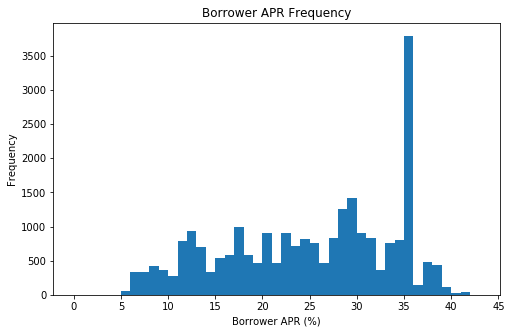

```python
# investigation of the most important feature - Borrower APR
# looking at the distribution
plt.figure(figsize=[8,5])
bins = np.arange(0, (comchar_loan3['BorrowerAPR']*100).max()+1, 1)
sb.distplot((comchar_loan3['BorrowerAPR']*100), bins = bins, kde = False, hist_kws = {'alpha' : 1})
plt.title('Borrower APR Frequency')
plt.ylabel('Frequency')
plt.xlabel('Borrower APR (%)')
plt.xticks(np.arange(0, 50, step=5));
```

> This plot means that more than 3500 borrowers have earned their loans with 35% annual percentage rate while no other APR has surpassed 1500 frequency.

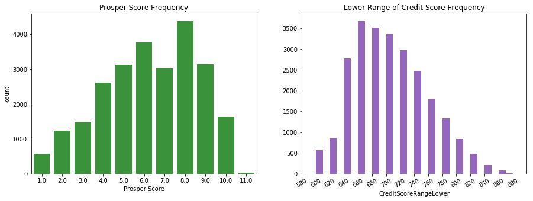

```python
# Now let's look at Prosper Score and credit score lower range
plt.figure(figsize=[15,5])

plt.subplot(1,2,1)
base_color = sb.color_palette()[2]
sb.countplot(data = comchar_loan3, x = 'ProsperScore', color = base_color)
plt.title('Prosper Score Frequency')
plt.xlabel('Prosper Score')

plt.subplot(1,2,2)
bins = np.arange(0, comchar_loan3['CreditScoreRangeLower'].max()+10, 10)
base_color = sb.color_palette()[4]
sb.distplot(comchar_loan3['CreditScoreRangeLower'], bins = bins, kde = False, hist_kws = {'alpha' : 1}, color = base_color)
plt.title('Lower Range of Credit Score Frequency')
plt.xlabel('CreditScoreRangeLower')
plt.xlim(580,900,20)
plt.xticks(np.arange(580, 900, step=20), rotation=30);
```

> More than 4000 borrowers have Prosper Score of 8 which is indicative of their trustworthiness by Prosper. I believe that the majority of these borrowers belong to completed loan status and not charged off. In the next step I will perform a query for charged-off loans to investigate the frequency of their Prosper Score. The majority of borrowers have credit score between 660 and 700. There is a steep decline in the number of borrowers with credit score lower than 640 which might be indicative of lack of trust by Prosper on borrowers with score below 640. On the other hand there is smooth decrease in frequency of credit score towards 880 which is mostly due to the lower number of people in the society with higher credit scores.

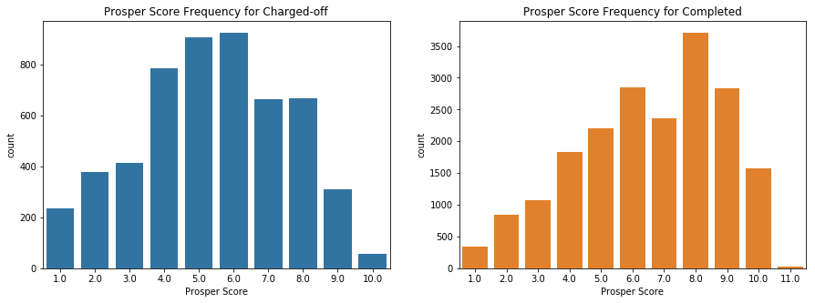

```python
# As mentioned above I'd like to make a query of charged-off loans and look at the propser scores of these borrowers.
plt.figure(figsize=[15,5])

plt.subplot(1,2,1)
df_chargedoff = comchar_loan3.query('LoanStatus == "Chargedoff"')
base_color = sb.color_palette()[0]
sb.countplot(data = df_chargedoff, x = 'ProsperScore', color = base_color)
plt.title('Prosper Score Frequency for Charged-off')
plt.xlabel('Prosper Score')

plt.subplot(1,2,2)
df_completed = comchar_loan3.query('LoanStatus == "Completed"')
base_color = sb.color_palette()[1]
sb.countplot(data = df_completed, x = 'ProsperScore', color = base_color)
plt.title('Prosper Score Frequency for Completed')
plt.xlabel('Prosper Score');
```

> As expected and mentioned above the borrowers with charged-off loan status are having a more normal distribution of frequency with a peak at prosper score of 5 and 6 while the borrowers with completed status have a left skewed frequency distribution with a peak at score of 8. Prosper Score is a measure of risk for loan and the higher the risk is lower This metric is achieved from historical Prosper data and obviously more borrowers with lower score and higher risk went into charged-off status compared to borrowers with lower risk. In the next step, I'd like to look at the ratio of employment status and the ratio of homeowners amongst the borrowers by generating pie chart and donut chart.

```python
# to find the categories of employment status
comchar_loan3['EmploymentStatus'].unique()
```

```
array(['Employed', 'Full-time', 'Not employed', 'Self-employed', 'Other',
       'Retired', 'Part-time'], dtype=object)
```

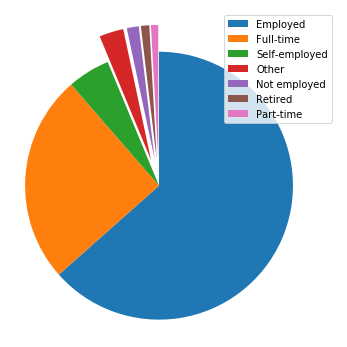

```python
# Pie chart to look at the ratio of employment status amongst borrowers
plt.figure(figsize=[6,6])

counts = comchar_loan3['EmploymentStatus'].value_counts()
explode = (0, 0, 0, 0.2, 0.2, 0.2, 0.2)
labels = ['Employed', 'Full-time', 'Self-employed', 'Other', 'Not employed', 'Retired', 'Part-time']
plt.pie(counts, startangle = 90, explode=explode, counterclock = False)
plt.legend(labels,loc=1)
plt.axis('square');
```

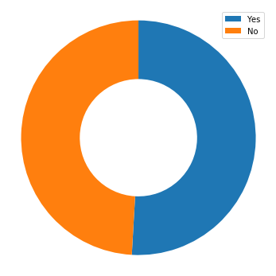

```python
# donut chart to look at the ratio of homeowners amongst borrowers
plt.figure(figsize=[6,6])

counts2 = comchar_loan3['IsBorrowerHomeowner'].value_counts()
labels = ['Yes', 'No']
plt.pie(counts2, startangle = 90, counterclock = False, wedgeprops = {'width' : 0.5})
plt.legend(labels,loc=1)
plt.axis('square');
```

> As shown above the majority of borrowers who has succeeded to obtain a loan either with completed or charged-off status were employed. Other important fact about the success of obtaining a loan is that it doesn't matter if the individual has been either retired or had part-time job. Their succes in approval of their loan has been low and not higher than individuals not having jobs. Employment status is obviously an important factor in receiving the loan. Between 50-55% of the borrowers were homeowners. Having a home is not a strong idicator of loan approval. Now that I explored the employment and homeownership I'd like to look at the occupations of the borrowers and their stated monthly income which is another important factor.

```python
# to find the categories of occupation
comchar_loan3['Occupation'].value_counts()[:10].index.tolist()
```

```
['Other',
 'Professional',
 'Computer Programmer',
 'Executive',
 'Administrative Assistant',
 'Analyst',
 'Accountant/CPA',
 'Teacher',
 'Sales - Commission',
 'Sales - Retail']
```

```python
# Query to obtain the top 10 most frequent occupations
comchar_loan4 = comchar_loan3.query('Occupation == "Other"|Occupation == "Professional"|Occupation == "Computer Programmer"|Occupation == "Executive"|Occupation == "Administrative Assistant"|Occupation == "Analyst"|Occupation == "Accountant/CPA"|Occupation == "Teacher"|Occupation == "Sales - Commission"|Occupation == "Sales - Retail"')
comchar_loan4['Occupation'].value_counts()
```

```
Other                       6460
Professional                3311
Computer Programmer         1227
Executive                    922
Administrative Assistant     893
Analyst                      892
Accountant/CPA               816
Teacher                      745
Sales - Commission           690
Sales - Retail               649
Name: Occupation, dtype: int64
```

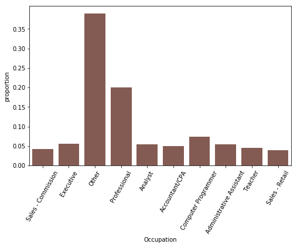

```python
# generate bar plot of proportions for occupations
plt.figure(figsize=[8,5])
n_obs = comchar_loan4.shape[0]
max_count = comchar_loan4['Occupation'].value_counts().max()
max_prop = max_count / n_obs

# generate tick mark locations and names
tick_props = np.arange(0, max_prop, 0.05)
tick_names = ['{:0.2f}'.format(v) for v in tick_props]

# create the plot
base_color = sb.color_palette()[5]
sb.countplot(data = comchar_loan4, x = 'Occupation', color = base_color)
plt.yticks(tick_props * n_obs, tick_names)
plt.ylabel('proportion');
plt.xticks(rotation=60);
```

```python
# Now let's look at the stated monthly income
comchar_loan3['IncomeRange'].unique()
```

```
array(['$25,000-49,999', '$75,000-99,999', '$100,000+', '$50,000-74,999',
       'Not employed', '$1-24,999', '$0'], dtype=object)
```

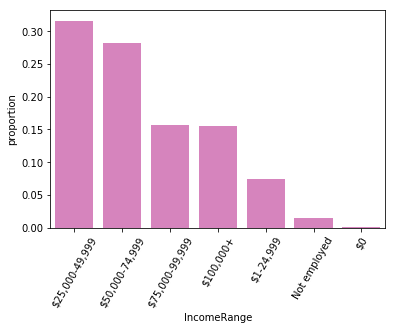

```python
# bar plot for income range
plt.figure(figsize=[6,4])
n_obs = comchar_loan3.shape[0]
max_count = comchar_loan3['IncomeRange'].value_counts().max()
max_prop = max_count / n_obs

# generate tick mark locations and names
tick_props = np.arange(0, max_prop, 0.05)
tick_names = ['{:0.2f}'.format(v) for v in tick_props]

# create the plot
base_color = sb.color_palette()[6]
order=comchar_loan3.IncomeRange.value_counts().index
sb.countplot(data = comchar_loan3, x = 'IncomeRange', color = base_color, order=order)
plt.yticks(tick_props * n_obs, tick_names)
plt.ylabel('proportion');
plt.xticks(rotation=60);
```

> Individuals not employed or having 0 income have minimal chance of getting a loan from Prosper. The proportion for income less than 25,000 is also less the 8%. The majority of the borrowers have income between 25,000 and 75,000 dollors which is reasonable in achieivng the loan since these people might be more in need and also have higher ability in returning the loan.

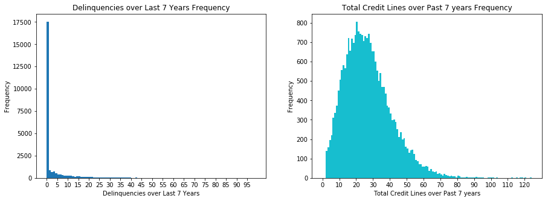

```python
# check hitogram of delinquencies and total credit lines over the past 7 years for outliers and if
# any data transformation is needed
plt.figure(figsize=[15,5])

plt.subplot(1,2,1)
bins = np.arange(0, comchar_loan3['DelinquenciesLast7Years'].max()+1, 1)
base_color = sb.color_palette()[0]
plt.hist(data = comchar_loan3, x = 'DelinquenciesLast7Years', bins = bins, color=base_color)
plt.title('Delinquencies over Last 7 Years Frequency')
plt.ylabel('Frequency')
plt.xlabel('Delinquencies over Last 7 Years')
plt.xticks(np.arange(0, 100, step=5))

plt.subplot(1,2,2)
bins = np.arange(0, comchar_loan3['TotalCreditLinespast7years'].max()+1, 1)
base_color = sb.color_palette()[9]
plt.hist(data = comchar_loan3, x = 'TotalCreditLinespast7years', bins = bins, color=base_color)
plt.title('Total Credit Lines over Past 7 years Frequency')
plt.ylabel('Frequency')
plt.xlabel('Total Credit Lines over Past 7 years')
plt.xticks(np.arange(0, 125, step=10));
```

> The above histograms are highly right skewed specifically Delinquencies over Last 7 Years. The number of individuals with 0 delinquency is close 17500 while the next highest peak is less than 1000. Many people might lose their chance of being approved for the loan with just 1 delinquency over the past 7 years. Moreover, based on Total Credit Lines over Past 7 Years histogram inviduals with 20 credit lines form the majority in the distribution. Seemingly, higher number of credit lines can increase the chances of being approved in the loan process. The gradual decline in the frequency with increasing number of credit lines might be relevant to lower number of applicants with more credit lines. There are outliers in these two datasets but first I'd like to disregard delinquencies equal to 0 to increase the graph resolution for individuals with higher delinquencies. On the next step I will log transform Total Credit Lines over Past 7 Years distribution.

```python
# Take a subset of Delinquencies over Last 7 Years dataset excluding delinquencies equal to 0.
delinquency_subset = comchar_loan3[comchar_loan3['DelinquenciesLast7Years'] > 0]
delinquency_subset.shape
```

```
(7448, 18)
```

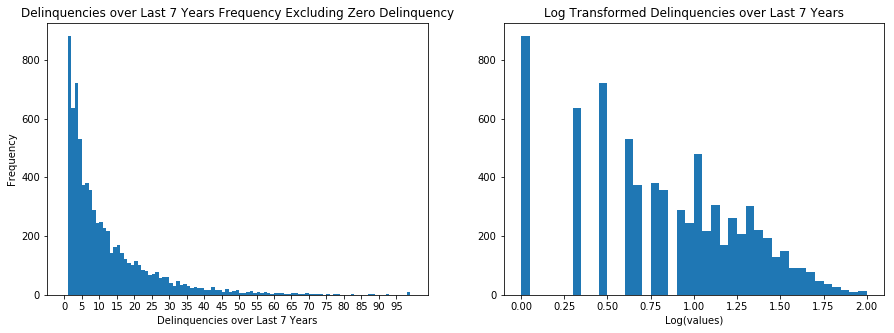

```python
# draw histogram of the subset
plt.figure(figsize=[15,5])

plt.subplot(1,2,1)
bins = np.arange(0, delinquency_subset['DelinquenciesLast7Years'].max()+1, 1)
base_color = sb.color_palette()[0]
plt.hist(data = delinquency_subset, x = 'DelinquenciesLast7Years', bins = bins, color=base_color)
plt.title('Delinquencies over Last 7 Years Frequency Excluding Zero Delinquency')
plt.ylabel('Frequency')
plt.xlabel('Delinquencies over Last 7 Years')
plt.xticks(np.arange(0, 100, step=5))

plt.subplot(1,2,2)
log_delinquency = np.log10(delinquency_subset['DelinquenciesLast7Years'])
log_bins = np.arange(0, log_delinquency.max()+0.05, 0.05)
plt.hist(log_delinquency, bins = log_bins)
plt.xlabel('Log(values)')
plt.title('Log Transformed Delinquencies over Last 7 Years');
```

> It seems that the data is transformed well for values above 1 (or above 10 for actual values) but it didn't work for values less than 1 (or 10 for actual dataset). I would say data is still highly skewed and might not be log-normally distributed. Now I'd like to log-transform Total Credit Lines over Past 7 years histogram.

```python
np.log10(comchar_loan3['TotalCreditLinespast7years'].max())
```

```
2.093421685162235
```

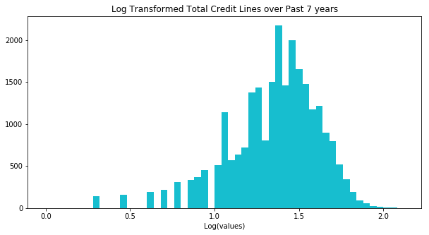

```python
# log transformation of Total Credit Lines over Past 7 years
plt.figure(figsize=[10,5])

log_credit = np.log10(comchar_loan3['TotalCreditLinespast7years'])
log_bins = np.arange(0, log_credit.max()+0.04, 0.04)
base_color = sb.color_palette()[9]
plt.hist(log_credit, bins = log_bins, color=base_color)
plt.xlabel('Log(values)')
plt.title('Log Transformed Total Credit Lines over Past 7 years');
```

> The distribution looks more normal after log transformation. The next step is checking distribution of trades without delinquency and total credit lines over the past 7 years

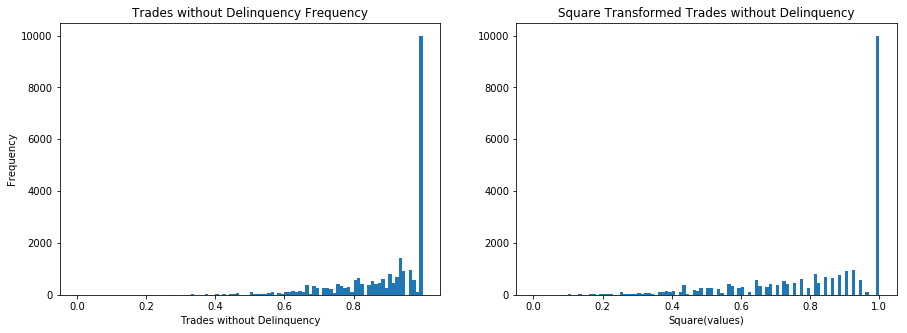

```python
# check hitogram of trades without delinquency and total credit lines over the past 7 years for outliers and if
# any data transformation is needed
plt.figure(figsize=[15,5])

#Original data distribution
plt.subplot(1,2,1)
bins = np.arange(0, comchar_loan3['TradesNeverDelinquent (percentage)'].max()+0.01, 0.01)
plt.hist(data = comchar_loan3, x = 'TradesNeverDelinquent (percentage)', bins = bins)
plt.title('Trades without Delinquency Frequency')
plt.ylabel('Frequency')
plt.xlabel('Trades without Delinquency')
plt.xticks(np.arange(0, 1, step=0.2))

# sqr transformation of data
plt.subplot(1,2,2)
sqr_comchar = np.square(comchar_loan3['TradesNeverDelinquent (percentage)'])
sqr_bins = np.arange(0, sqr_comchar.max()+0.01, 0.01)
plt.hist(sqr_comchar, bins = sqr_bins)
plt.xlabel('Square(values)')
plt.title('Square Transformed Trades without Delinquency');
```

```python
# Log transformation of TradesNeverDelinquent (percentage) data was not possible since all data was between 0 and 1. I decided
# to perform sqaure transformation. The data still looks left skewed and I'm not satisfied with the transformation.
# I decide to look at data distribution between 0 and 0.99 since I'm already aware of individuals with trades with
# no delinquency (10000).
trade_subset = comchar_loan3[comchar_loan3['TradesNeverDelinquent (percentage)'] < 1]
trade_subset.shape
```

```
(14992, 18)
```

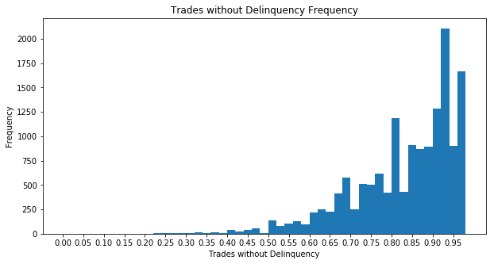

```python
# histogram of Trades without Delinquency with percentage lower than 100.
plt.figure(figsize=[10,5])
bins = np.arange(0, trade_subset['TradesNeverDelinquent (percentage)'].max()+0.02, 0.02)
plt.hist(data = trade_subset, x = 'TradesNeverDelinquent (percentage)', bins = bins)
plt.title('Trades without Delinquency Frequency')
plt.ylabel('Frequency')
plt.xlabel('Trades without Delinquency')
plt.xticks(np.arange(0, 1, step=0.05));
```

> The distribution of Trades without Delinquency is highly skewed to the left which is reasonable. It is evident that people with trades without delinquency less than 50% has much lower chance of being approved for loan by Prosper. As we seen earlier there is a huge spike for inviduals with 100% Trades without Delinquency with frequency around 10000. The next highest peak in this distribution is between 90 and 95% which is still high percentage but much lower in frequency (2000) compared to the first peak. Interestingly, if the person has had one time delinquency in their trades deore they might lose a lot of chance being approved in the loan process. I'd also like to check the duration o employment status.

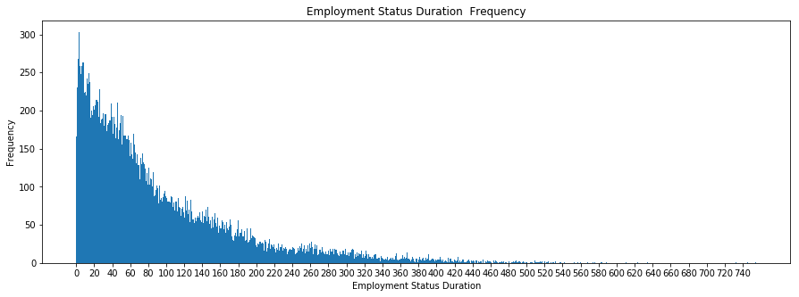

```python
# employment status duration
plt.figure(figsize=[15,5])
bins = np.arange(0, comchar_loan3['EmploymentStatusDuration'].max()+1, 1)
plt.hist(data = comchar_loan3, x = 'EmploymentStatusDuration', bins = bins)
plt.title('Employment Status Duration  Frequency')
plt.ylabel('Frequency')
plt.xlabel('Employment Status Duration')
plt.xticks(np.arange(0, 755, step=20));
```

```python
# taking a subset of data to see at what employment duration the eligibility of inviduals starts to drop.
employment_sub = comchar_loan3[comchar_loan3['EmploymentStatusDuration']<25]
employment_sub.shape
```

```
(5728, 18)
```

[figure not shown]

```python
# employment status duration histogram for less than 24 months
plt.figure(figsize=[15,5])
bins = np.arange(0, employment_sub['EmploymentStatusDuration'].max()+0.1, 0.1)
plt.hist(data = employment_sub, x = 'EmploymentStatusDuration', bins = bins)
plt.title('Employment Status Duration  Frequency for Less than 12 Months')
plt.ylabel('Frequency')
plt.xlabel('Employment Status Duration')
plt.xticks(np.arange(0, 25, step=1));
```

> And finally it seems that individuals with 3 months employment are more present in the pool of borrowers. It seems that even with 1 month of employment individuals' eligibility wouldn't be less than others with longer period of employment.

### Of the features you investigated, were there any unusual distributions? Did you perform any operations on the data to tidy, adjust, or change the form of the data? If so, why did you do this?

> I inspected a couple of categorical and numerical variables that some of them high skewness. For example, Delinquencies over Last 7 Years showed very high right skewed distribution and I also needed to exclude delinquencies equal to 0 to better inspect the distribution of the variable. Moreover, Total Credit Lines over Past 7 years was right skewed. I performed log transformation of data and it turned into a normal distribution.

## Bivariate Exploration

> Usually creating a plot and correlation matrices for variables of interest gives a better understanding of the relation between them. Before running any bivariate exploration I'd like to generate a plot matrix.

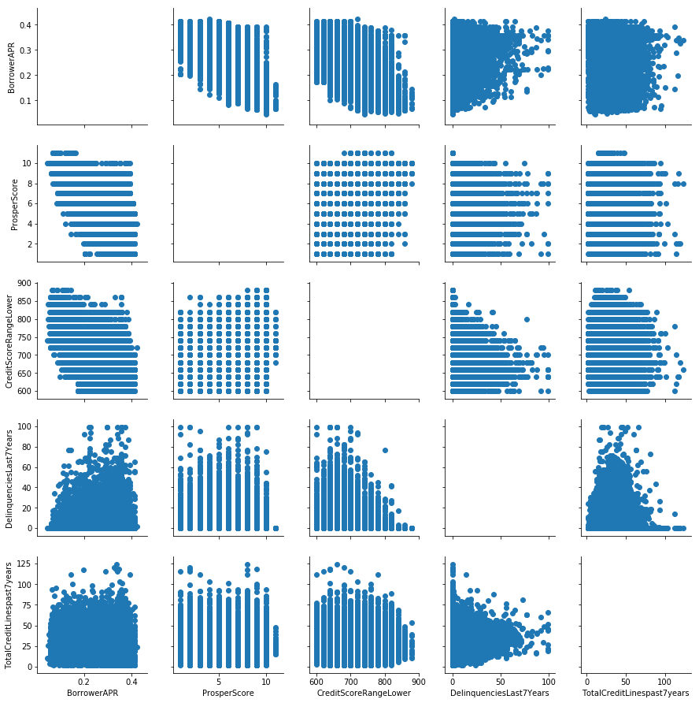

```python
# Create plot matrix between variables of interest
J = sb.PairGrid(data = comchar_loan3, vars = ['BorrowerAPR', 'ProsperScore', 'CreditScoreRangeLower',
                                              'DelinquenciesLast7Years', 'TotalCreditLinespast7years'])
J.map_offdiag(plt.scatter);
```

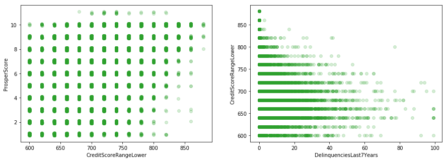

```python
# Inspect the relation between Prosper Score and Lower Range Credit Score by adding jitter and alpha to the plot
plt.figure(figsize=[15,5])

plt.subplot(1,2,1)
base_color = sb.color_palette()[2]
sb.regplot(data = comchar_loan3, x = 'CreditScoreRangeLower', y = 'ProsperScore', fit_reg = False,
           x_jitter = 0.3, y_jitter = 0.1, scatter_kws = {'alpha' : 1/5}, color = base_color)

plt.subplot(1,2,2)
base_color = sb.color_palette()[2]
sb.regplot(data = comchar_loan3, x = 'DelinquenciesLast7Years', y = 'CreditScoreRangeLower', fit_reg = False,
        scatter_kws = {'alpha' : 1/5}, color = base_color);
```

> The number of observations is too high and lots of data points overlap in the scatter plots. So I decided to inspect the graphs with addition of jitter and alpha. Before looking at the relationship between borrower APR and variables of interest I'd like to inspect the relation between variables of interest. Although the relation doesn't seem to be so strong but the trend is obvious between Prosper Score and Credit Score Lower Range. There are not a lot of people with high credit score (above 800) who have prosper score lower than 5. On the other hand, it doesn't seem that on the lower range there is a strong relation between these two variables. We can see people with even very high prosper score have very low credit score. One opinion comes to my mind is that people might be good customer with prosper with very positive background but on other transactions with other instituitions might have not been a good customer. Other variables are a player here that could confound the relationship between these two variables. The same issue is present in the relationship between credit score and delinquencies over the past 7 years. But interestingly it can be seen that more people with scores between 650 and 700 have higher delinquencies. The graph can be devided into two parts. The lower part with scores less than 680 and the part with scores higher than 680. The increasing trend of delinquencies with credit score in the lower part might be due the Prosper's decision to release loans to people with better scores although they might have more delinquencies. On the other hand, in the upper part of the graph we see a decreasing trend of delinquencies with increasing credit score. This is due to the borrowers themselves. People with higher score tend to have lower delinquencies in general. It is not so probable to see many people with delinquencies more than 40 and credit score higher than 750.

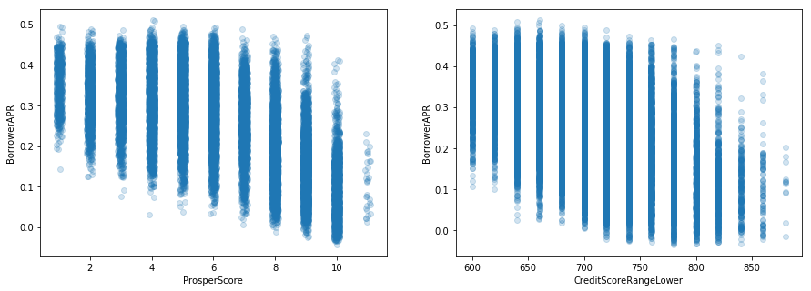

```python
# Inspect the relation between borrower APR and other variables of interest
plt.figure(figsize=[15,5])

plt.subplot(1,2,1)
sb.regplot(data = comchar_loan3, x = 'ProsperScore', y = 'BorrowerAPR', fit_reg = False,
           x_jitter = 0.1, y_jitter = 0.1, scatter_kws = {'alpha' : 1/5})

plt.subplot(1,2,2)
sb.regplot(data = comchar_loan3, x = 'CreditScoreRangeLower', y = 'BorrowerAPR', fit_reg = False,
        x_jitter = 0.1, y_jitter = 0.1, scatter_kws = {'alpha' : 1/5});
```

> The relationship between borrower APR and both prosper score and credit score is generally negative. It doesn't seem to be very strong relationshp but still as expected from previous results both higher credit score and prosper score reduce the APR on loan which is reasonable. Looking at the lower range of APR on the first graph with increasing prosper score the APR reduces in a linear fasion. There is almost no borrower with prosper score of 1 who earned the loan with APR less than 20%. On the other hand, people with prosper score of 10 are drastically reduced in numbers when APR is increased. The same story and trends can be observed from the relation between APR and credit score. No borrower has achieved their loan with APR less than 10% if their credit score has been 600. On the other hand, not a lot of borrowers have achieved their loan with APR higher than 20% if their credit score have been around 850.

```python
# take a subset of data for delinquencies below 40
delin_subset = comchar_loan3[comchar_loan3['DelinquenciesLast7Years'] < 40]
delin_subset.shape
```

```
(24664, 18)
```

```python
# take a subset of data for total credit lines below 60
credit_sub = comchar_loan3[comchar_loan3['TotalCreditLinespast7years'] < 60]
credit_sub.shape
```

```
(24374, 18)
```

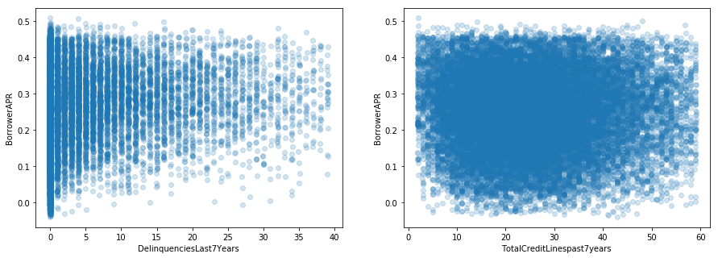

```python
# Inspect the relation between borrower APR and other variables of interest
plt.figure(figsize=[15,5])

plt.subplot(1,2,1)
sb.regplot(data = delin_subset, x = 'DelinquenciesLast7Years', y = 'BorrowerAPR', fit_reg = False,
           x_jitter = 0.1, y_jitter = 0.1, scatter_kws = {'alpha' : 1/5})

plt.subplot(1,2,2)
sb.regplot(data = credit_sub, x = 'TotalCreditLinespast7years', y = 'BorrowerAPR', fit_reg = False,
        x_jitter = 0.1, y_jitter = 0.1, scatter_kws = {'alpha' : 1/5});
```

> In general the number of borowers reduces with increasing number of delinquencies over the last 7 years but a treand of increasing APR can be observed for incerasing number of delinquencies. Many other variables might confound the relation between these two, for example credit score. No visible trend can be seen for total credit lines and APR but the majority of borrowers are within a circle ranging from 5 to 40 for number of credit lines and 5 to 40% for borrower APR.

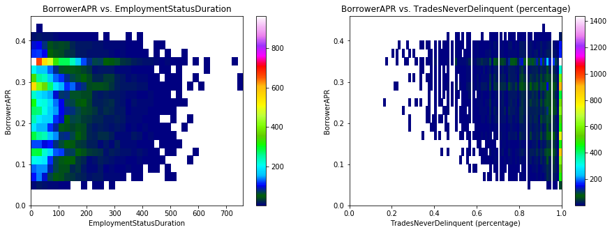

```python
# darw heatmaps of borrower APR vs employment status duration and percentage of trades never delinquent.
plt.figure(figsize=[15,5])

plt.subplot(1,2,1)
bins_x = np.arange(0, comchar_loan3['EmploymentStatusDuration'].max()+20, 20)
bins_y = np.arange(0, comchar_loan3['BorrowerAPR'].max()+0.05, 0.02)
plt.hist2d(data = comchar_loan3, x = 'EmploymentStatusDuration', y = 'BorrowerAPR', bins = [bins_x, bins_y],
               cmap = 'gist_ncar', cmin = 0.5)
plt.colorbar()
plt.title('BorrowerAPR vs. EmploymentStatusDuration')
plt.xlabel('EmploymentStatusDuration')
plt.ylabel('BorrowerAPR')

plt.subplot(1,2,2)
bins_x = np.arange(0, comchar_loan3['TradesNeverDelinquent (percentage)'].max()+0.01, 0.01)
bins_y = np.arange(0, comchar_loan3['BorrowerAPR'].max()+0.05, 0.02)
plt.hist2d(data = comchar_loan3, x = 'TradesNeverDelinquent (percentage)', y = 'BorrowerAPR', bins = [bins_x, bins_y],
               cmap = 'gist_ncar', cmin = 0.5)
plt.colorbar()
plt.title('BorrowerAPR vs. TradesNeverDelinquent (percentage)')
plt.xlabel('TradesNeverDelinquent (percentage)')
plt.ylabel('BorrowerAPR');
```

```python
# take a subset of dataset and increase the resolution of heat maps.
employment_subset = comchar_loan3[comchar_loan3['EmploymentStatusDuration'] < 400]
employment_subset.shape
```

```
(24734, 18)
```

```python
# take a subset of dataset and increase the resolution of heat maps.
trades_subset = comchar_loan3[comchar_loan3['TradesNeverDelinquent (percentage)'] > 0.6]
trades_subset.shape
```

```
(24083, 18)
```

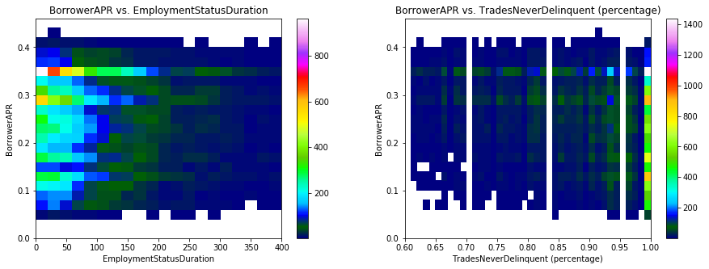

```python
# draw the heat maps again for APR vs employment duration and trades never delinquent
plt.figure(figsize=[15,5])

plt.subplot(1,2,1)
bins_x = np.arange(0, employment_subset['EmploymentStatusDuration'].max()+20, 20)
bins_y = np.arange(0, employment_subset['BorrowerAPR'].max()+0.05, 0.02)
plt.hist2d(data = employment_subset, x = 'EmploymentStatusDuration', y = 'BorrowerAPR', bins = [bins_x, bins_y],
               cmap = 'gist_ncar', cmin = 0.5)
plt.colorbar()
plt.title('BorrowerAPR vs. EmploymentStatusDuration')
plt.xlabel('EmploymentStatusDuration')
plt.ylabel('BorrowerAPR')

plt.subplot(1,2,2)
bins_x = np.arange(0, trades_subset['TradesNeverDelinquent (percentage)'].max()+0.01, 0.01)
bins_y = np.arange(0, trades_subset['BorrowerAPR'].max()+0.05, 0.02)
plt.hist2d(data = trades_subset, x = 'TradesNeverDelinquent (percentage)', y = 'BorrowerAPR', bins = [bins_x, bins_y],
               cmap = 'gist_ncar', cmin = 0.5)
plt.colorbar()
plt.xlim(0.6,1)
plt.title('BorrowerAPR vs. TradesNeverDelinquent (percentage)')
plt.xlabel('TradesNeverDelinquent (percentage)')
plt.ylabel('BorrowerAPR');
```

> One observation is that irrespective of the relationship between APR and other variables, at 35% APR the number of borrowers is drastically higher than other APRs but still with increase in employment duration and reduction in trades never delinquent at this APR the number of borrowers decreases.

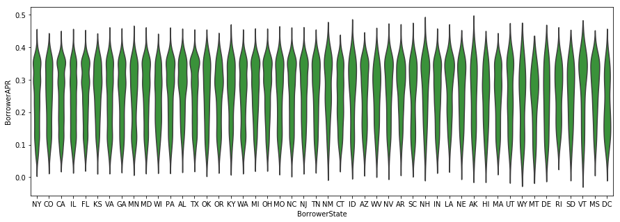

```python
# draw violin plot for APR and borrower states.
plt.figure(figsize=[15,5])
base_color = sb.color_palette()[2]
sb.violinplot(data = comchar_loan3, x = 'BorrowerState', y = 'BorrowerAPR', color = base_color,
              inner = None);
```

> In the above violin plot I wanted to inspect the effect of states in borrower APR so maybe borrower state would be a confounding factor in the relationship between APR and other variables but as it is evident all the states look the same in terms of borrower APR. In the next step I'll ook into the relation between APR and other variables using boxplots.

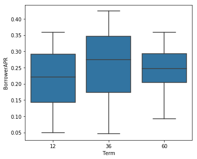

```python
# draw box plots for APR and terms
plt.figure(figsize=[6,5])
base_color = sb.color_palette()[0]
sb.boxplot(data = comchar_loan3, x = 'Term', y = 'BorrowerAPR', color = base_color);
```

```python
# bring list of income ranges to put them in order in the box plot
comchar_loan3['IncomeRange'].unique()
```

```
array(['$25,000-49,999', '$75,000-99,999', '$100,000+', '$50,000-74,999',
       'Not employed', '$1-24,999', '$0'], dtype=object)
```

```python
# putting values for income range in order
income_orders = ['Not employed','$0','$1-24,999','$25,000-49,999','$50,000-74,999','$75,000-99,999','$100,000+']
inorders = pd.api.types.CategoricalDtype(ordered = True, categories = income_orders)
comchar_loan3['IncomeRange'] = comchar_loan3['IncomeRange'].astype(inorders)
```

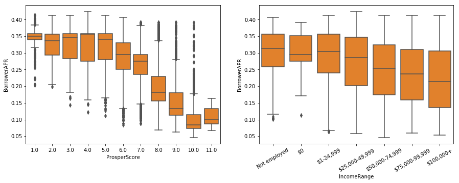

```python
# draw box plots for APR vs Prosper score and income range
plt.figure(figsize=[15,5])

plt.subplot(1,2,1)
base_color = sb.color_palette()[1]
sb.boxplot(data = comchar_loan3, x = 'ProsperScore', y = 'BorrowerAPR', color = base_color)

plt.subplot(1,2,2)
base_color = sb.color_palette()[1]
sb.boxplot(data = comchar_loan3, x = 'IncomeRange', y = 'BorrowerAPR', color = base_color)
plt.xticks(rotation=30);
```

```python
# take a subset of dataset with Prosper score of 10 and 1 to re-draw the boxplot for income ranges and possibly see the difference
# between different brackets
prosper_subset10 = comchar_loan3[comchar_loan3['ProsperScore'] == 10]
print(prosper_subset10.shape)
prosper_subset1 = comchar_loan3[comchar_loan3['ProsperScore'] == 1]
print(prosper_subset1.shape)
```

```
(1632, 18)
(576, 18)
```

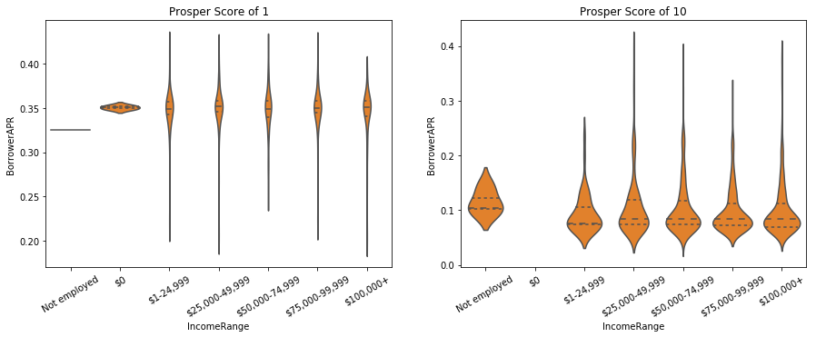

```python
# draw violin plots of APR vs income ranges for Propser score of 10 and 1
plt.figure(figsize=[15,5])

plt.subplot(1,2,1)
base_color = sb.color_palette()[1]
sb.violinplot(data = prosper_subset1, x = 'IncomeRange', y = 'BorrowerAPR', color = base_color, inner = 'quartile')
plt.xticks(rotation=30)
plt.title('Prosper Score of 1')

plt.subplot(1,2,2)
base_color = sb.color_palette()[1]
sb.violinplot(data = prosper_subset10, x = 'IncomeRange', y = 'BorrowerAPR', color = base_color, inner = 'quartile')
plt.xticks(rotation=30)
plt.title('Prosper Score of 10');
```

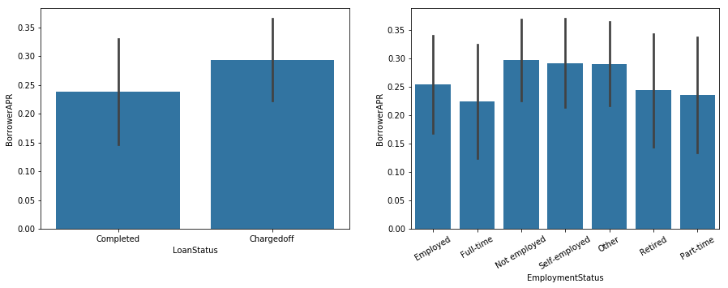

```python
# bar plots with standard deviations of borrower APR vs loan status and employment status
plt.figure(figsize=[15,5])

plt.subplot(1,2,1)
base_color = sb.color_palette()[0]
sb.barplot(data = comchar_loan3, x = 'LoanStatus', y = 'BorrowerAPR', color = base_color, ci='sd');

plt.subplot(1,2,2)
base_color = sb.color_palette()[0]
sb.barplot(data = comchar_loan3, x = 'EmploymentStatus', y = 'BorrowerAPR', color = base_color, ci='sd')
plt.xticks(rotation=30);
```

> Charged-off loans were already approved with higher APR while completed loans were having lower APR. This is indicative of prior knowledge of Prosper of higher risk borrowers who couldn't potentially pay off their debts so they were provided loans with higher borrower APR. On the other hand borrowers with employed status and also full time jobs were having lower APR loans compared to borrowers who were not employed or self employed. It seems that Prosper trusts borrowers with full time jobs rather than borrowers who are self employed or not employed. Now let's generate a correlation matrix to wrap up our bivariate analysis.

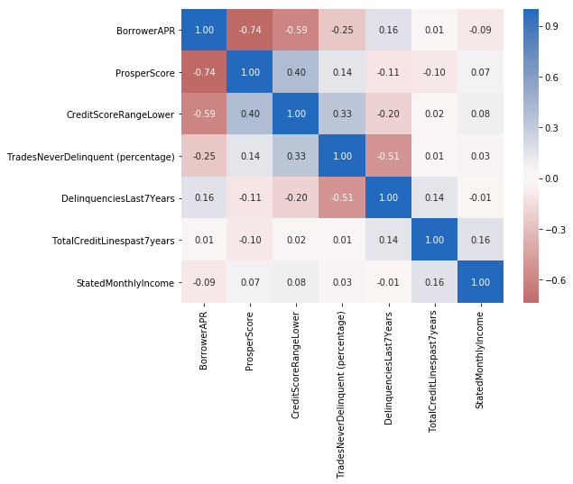

```python
# correlation matrix between variables of interest
plt.figure(figsize=[8,6])
selected = ['BorrowerAPR', 'ProsperScore', 'CreditScoreRangeLower', 'TradesNeverDelinquent (percentage)',
                         'DelinquenciesLast7Years', 'TotalCreditLinespast7years', 'StatedMonthlyIncome']
sb.heatmap(comchar_loan3[selected].corr(), annot = True, fmt = '.2f', cmap = 'vlag_r', center = 0);
```

> Borrower APR has the highest correlation with Prosper score and credit score lower range with correlation coefficient of -0.74 and -0.59, respectively. As seen earlier the higher prosper score and credit score range lower the lower the borrower APR would be and it can be seen in the above correlation matrix. The correlation between APR and variables is not as strong as these two variables. Prosper score and credit score range lower have correlation coefficient of 0.4 which is accounted as moderate correlation and might be indicative of collinearity. This might be party due to the inclusion of credit score into the Prosper score. Trades never delinquent also have negative correlation of -0.51 with delinquencies over the past 7 years.

### Talk about some of the relationships you observed in this part of the investigation. How did the feature(s) of interest vary with other features in the dataset?

> As observed earlier borrower APR is highly correlated with Prosper score and credit score lower range. The relationship has been described in detail with generation of sb.regplot and correlation matrix. One observation is that irrespective of the relationship between borrower APR and other variables, at 35% APR the number of borrowers is drastically higher than other APRs but still with increase in employment duration and reduction in trades never delinquent at this APR the number of borrowers decreases. I have also observed that with increase in Prosper score the borrower APR tends to decrease. This is more obvious for Prosper score above 5. Charged-off loans have had higher borrower APR compared to completed loans. Prosper knew the high risk of this loans and increased their APR.

### Did you observe any interesting relationships between the other features (not the main feature(s) of interest)?

> Prosper score and credit score lower range have moderate positive correlation which might be indicative of collinearity and inclusion of credit score in Prosper score. The relationship between delinquencies over the past 7 years and trades never delinquent has also been explored which were negatively correlated.

## Multivariate Exploration

> In this section I'd like to perform multivarate exploratory analysis of three or more variables. First I want to incorporate Prosper score into the relationship between borrower APR vs credit score range lower and delinquencies over past 7 years.

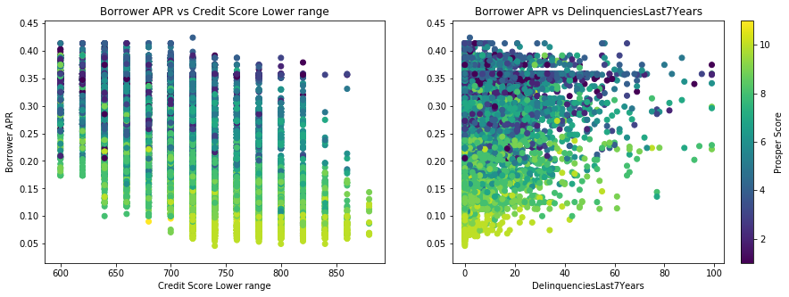

```python
# draw mutivariate scatter plot between borrower APR vs credit score range lower and delinquencies over past 7 years
# via incorporation of Prosper score
plt.figure(figsize=[15,5])

plt.subplot(1,2,1)
plt.scatter(data = comchar_loan3, x = 'CreditScoreRangeLower', y = 'BorrowerAPR', c = 'ProsperScore')
plt.title('Borrower APR vs Credit Score Lower range')
plt.ylabel('Borrower APR')
plt.xlabel('Credit Score Lower range')

plt.subplot(1,2,2)
plt.scatter(data = comchar_loan3, x = 'DelinquenciesLast7Years', y = 'BorrowerAPR', c = 'ProsperScore')
plt.colorbar(label='Prosper Score')
plt.title('Borrower APR vs DelinquenciesLast7Years')
plt.xlabel('DelinquenciesLast7Years');
```

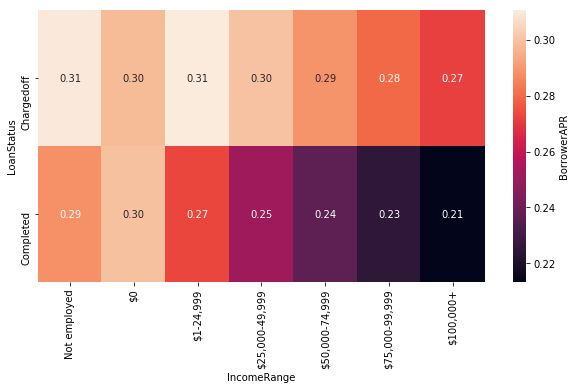

```python
# darw facet grid of boxplots for variables of interest
plt.figure(figsize=[10,5])
cat = comchar_loan3.groupby(['IncomeRange', 'LoanStatus']).mean()['BorrowerAPR']
cat = cat.reset_index(name = 'BorrowerAPR')
cat = cat.pivot(index = 'LoanStatus', columns = 'IncomeRange',
                            values = 'BorrowerAPR')
sb.heatmap(cat, annot = True, fmt = '.2f',
           cbar_kws = {'label' : 'BorrowerAPR'});
```

> Obviously borrower APR was the lowest for highest bracket of income and completed loans and highest for not employed borrowers whose loans got charged off.

```python
# putting values for income range in order
income_orders = ['Not employed','$0','$1-24,999','$25,000-49,999','$50,000-74,999','$75,000-99,999','$100,000+']
inorders = pd.api.types.CategoricalDtype(ordered = True, categories = income_orders)
comchar_loan4['IncomeRange'] = comchar_loan4['IncomeRange'].astype(inorders)
```

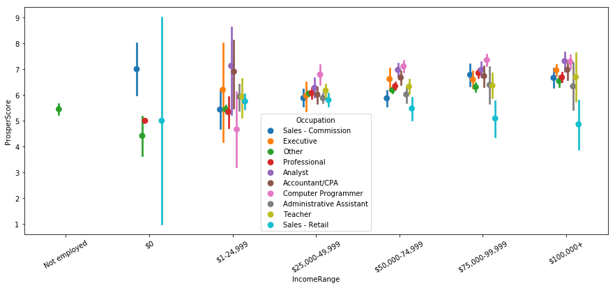

```python
# draw point plot of Prosper score and income range and occupation
plt.figure(figsize=[15,6])
sb.pointplot(data = comchar_loan4, x = 'IncomeRange', y = 'ProsperScore', hue = 'Occupation',
                  dodge = 0.3, linestyles = "")
plt.xticks(rotation=30);
```

> Computer programmers look to have higher Prosper score compared to other top 10 occupations (in terms of frequency) in most of the income brackets except 1-24,000 dollars. The first bracket of 1-24,999 actually has higher variability comapred to other brackets. The lowest Prosper score belongs to sales-retail in most of the brackets. In general the Prosper score tends to increase for most of the occupations except sales-retail.

### Talk about some of the relationships you observed in this part of the investigation. Were there features that strengthened each other in terms of looking at your feature(s) of interest?

> Multivariate analysis has been in favor of the bivariate analysis.As described earlier the highest correlation coefficient belongs to Prosper score which showed its effect in the scatter plots of borrower APR vs credit score lower range and delinquencies over the past 7 years. Borrower APR was the lowest for highest bracket of income and completed loans and highest for not employed borrowers whose loans got charged off. Other variables were not of very high interest after the bivariate analysis.

### Were there any interesting or surprising interactions between features?

> Prosper score showed an incerasing trend with increasing income bracket for most of the occupations. The only occupation with decreasing trend in Prosper score was sales-retail.